# Tipos de análisis de datos

En general sin importar el tamaño de tu conjunto de datos vamos a encontrar que se pueden dividir en 4 partes:

1. Analítica descriptiva
2. Analítica diagnóstica
3. Analítica predictiva
4. Analítica prescriptiva

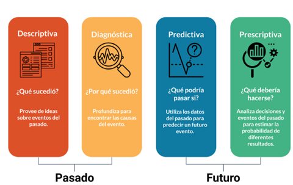

- La **analítica descriptiva** me va ayudar a darme ideas sobre lo que ya sucedió.
- Me va a ayudar a profundizar en las causas que me llevaron a un tipo de evento.
- En la predictiva consiste en hablar sobre el futuro ¿que pasaría si? o ¿que podría pasar si? se apoya de usar los datos del pasado para poder predecir el futuro.
- En la parte de la prescriptiva busca tomar decisiones sobre que hacer, analizando las decisiones de eventos del pasado para poder mejorar en el futuro.

Así pues todo esto lleva tiempo y cada etapa de la analítica se va a construir una sobre la para, es decir no se podría pasar directamente a **prescribir** el problema sin aún **describirlo**; es decir no podemos predecir algún problema sin siquiera saber que existe o diagnosticarlo. No es lógico pasar a etapas finales sin hacer las bases, entonces necesitamos llevar un control de los pasos.

En general más allá del incremento de tiempo, hay un incremento en la complejidad

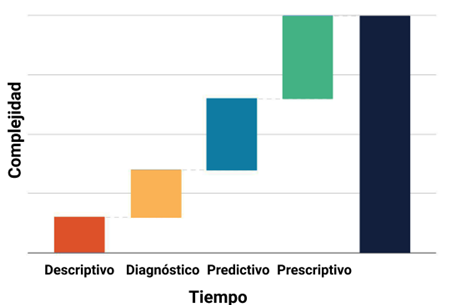

Porque conforme pase el tiempo necesitaremos entender cada vez más los datos a un nivel más preciso y profundo, para lograr tomar decisiones basadas en los datos y poder cambiar el rumbo del proyecto, empresa o cualquier tarea que te encuentres realizando.

## Extras:

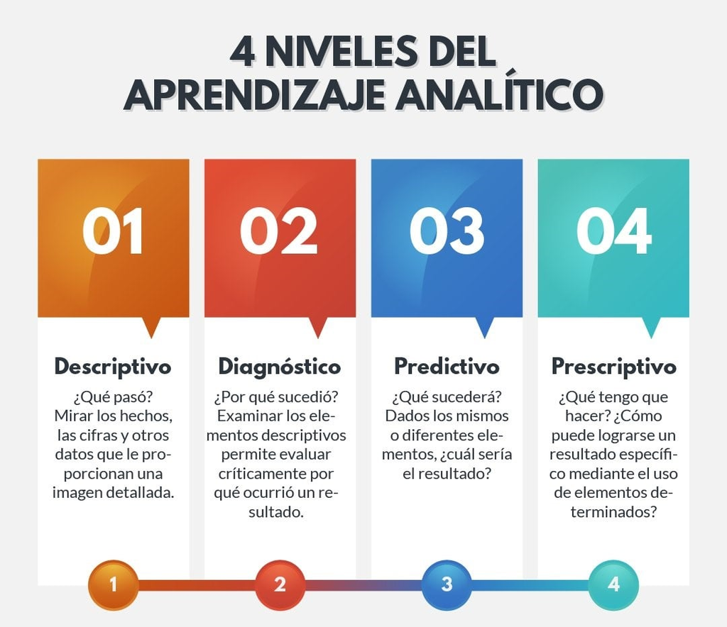

## [¿Cuáles son los tipos de análisis de Big Data existentes para aplicar en los negocios?](https://blog-es.lac.tdsynnex.com/cuales-son-los-tipos-de-analisis-de-big-data-existentes-para-aplicar-en-los-negocios)

Para que sea posible usar todos los beneficios del Big Data, es necesario conocer cuáles tipos de análisis se pueden utilizar. Descúbrelo a continuación:

### Análisis predictivo

Desde un conjunto de datos, los algoritmos de ese tipo de análisis logran identificar patrones y posibles tendencias de mercado. De este modo, las empresas pueden utilizarlo para realizar previsiones.

Es una excelente opción para estudiar las condiciones de mercado, buscar sugerencias de consumo para tus clientes, identificando su perfil, sus necesidades y deseos.

### Análisis prescriptivo

En cambio, el modelo prescriptivo es capaz de identificar cuáles serán las consecuencias de las acciones tomadas por las empresas. Ayuda a los gestores a anticipar las posibles reacciones de su público, lo cual permite que las estrategias utilizadas sean mejor dirigidas.

De esta forma, las empresas pueden realizar simulaciones y anticipar sus acciones para determinar escenarios, lo cual puede mejorar considerablemente los resultados de los negocios.

### Análisis descriptivo

El análisis descriptivo se enfoca en entender la situación actual de la empresa. Ofrece a los gestores un panorama completo y en tiempo real, de los sucesos internos y de la posición de la organización en el mercado.

Por medio de éste, es posible visualizar el escenario económico en tiempo real. De esta manera, los gestores pueden tomar decisiones con base en información correcta y precisa.

### Análisis diagnóstico

Por último, podemos citar el análisis diagnóstico, el cual prioriza un mapeo de las causas y consecuencias de las acciones de la empresa en relación con su situación actual.

Es una excelente opción para cuando los gestores de TI necesitan mostrar los resultados del desempeño de la organización y explicar cómo está en el presente.

Al contar con diagnósticos precisos, los líderes de la empresa pueden definir acciones correctivas para solucionar temas específicos y, de esta forma, optimizar los negocios.

Como puede ver, los análisis de Big Data generan oportunidades para que las organizaciones crezcan y se destaquen en el mercado. Por esto, es esencial conocer los tipos existentes y dirigirlos mejor en las estrategias internas para alcanzar mejores resultados.

### [Types of Data Analysis](https://chartio.com/learn/data-analytics/types-of-data-analysis/)